# Рынок заведений общественного питания Москвы

Инвесторы из фонда «Shut Up and Take My Money» решили попробовать себя в новой области и открыть заведение общественного питания в Москве. Заказчики ещё не знают, что это будет за место: кафе, ресторан, пиццерия, паб или бар, — и какими будут расположение, меню и цены. Моя задача как аналитика подготовить исследование рынка Москвы, найти интересные особенности и презентовать полученные результаты, которые в будущем помогут в выборе подходящего инвесторам места.

Мне доступен датасет с заведениями общественного питания Москвы, составленный на основе данных сервисов Яндекс Карты и Яндекс Бизнес на лето 2022 года. Информация, размещённая в сервисе Яндекс Бизнес, могла быть добавлена пользователями или найдена в общедоступных источниках.

Для начала загрузим данные и изучим общую информацию: посмотрим, сколько заведений предствалено, какие существуют столбцы, какого типа значения они хранят.

Затем выполним предобработку данных - изучим, есть ли дубликаты в данных, поищете пропуски и посмотрим, оставлять их как есть или удалить, также посмотрим на формат столцов - соответстсвует ли он удобному типу данных Создадим столбец street с названиями улиц из столбца с адресом. Создадим столбец is_24/7 с обозначением, что заведение работает ежедневно и круглосуточно (24/7): логическое значение True — если заведение работает ежедневно и круглосуточно; логическое значение False — в противоположном случае.

Необязательное задание: проиллюстрируйте другие взаимосвязи, которые вы нашли в данных. Например, по желанию исследуйте часы работы заведений и их зависимость от расположения и категории заведения. Также можно исследовать особенности заведений с плохими рейтингами, средние чеки в таких местах и распределение по категориям заведений. Соберите наблюдения по вопросам выше в один общий вывод.

Детализируем исследование: открытие кофейни Основателям фонда «Shut Up and Take My Money» не даёт покоя успех сериала «Друзья». Их мечта — открыть такую же крутую и доступную, как «Central Perk», кофейню в Москве. Будем считать, что заказчики не боятся конкуренции в этой сфере, ведь кофеен в больших городах уже достаточно. Попробуйте определить, осуществима ли мечта клиентов. Проведем маркетинговый анали: Сколько всего кофеен в датасете? В каких районах их больше всего, каковы особенности их расположения? Есть ли круглосуточные кофейни? Какие у кофеен рейтинги? Как они распределяются по районам? На какую стоимость чашки капучино стоит ориентироваться при открытии и почему?

По желанию вы можете расширить список вопросов для исследования, добавив собственные. Постройте визуализации. Попробуйте дать рекомендацию для открытия нового заведения. Это творческое задание: здесь нет правильного или неправильного ответа, но ваше решение должно быть чем-то обосновано. Объяснить свою рекомендацию можно текстом с описанием или маркерами на географической карте.

импортируем библиотеки

```python
import pandas as pd
import matplotlib.pyplot as plt
import seaborn as sns
import folium
import json
```

```python
# Шаг 1: Загрузка данных и изучение общей информации
data = pd.read_csv('/datasets/moscow_places.csv')
```

```python
# Вывод общей информации о датасете
print(data.info())
```

```
<class 'pandas.core.frame.DataFrame'>
RangeIndex: 8406 entries, 0 to 8405
Data columns (total 14 columns):
 #   Column             Non-Null Count  Dtype
---  ------             --------------  -----
 0   name               8406 non-null   object
 1   category           8406 non-null   object
 2   address            8406 non-null   object
 3   district           8406 non-null   object
 4   hours              7870 non-null   object
 5   lat                8406 non-null   float64
 6   lng                8406 non-null   float64
 7   rating             8406 non-null   float64
 8   price              3315 non-null   object
 9   avg_bill           3816 non-null   object
 10  middle_avg_bill    3149 non-null   float64
 11  middle_coffee_cup  535 non-null    float64
 12  chain              8406 non-null   int64
 13  seats              4795 non-null   float64
dtypes: float64(6), int64(1), object(7)
memory usage: 919.5+ KB
None
```

Ячейки зазваны удобно и понятно, типы данных соответстсвуют, менять ничего не нужно. Вижу некоторое количество нулевых значений, нужно посмотреть поближе

```python
# Вывод количества заведений
num_places = len(data)
print("Количество заведений:", num_places)
```

```
Количество заведений: 8406
```

Проверим на дубликаты

```python
# Шаг 2: Предобработка данных
# Проверка наличия дубликатов
duplicates = data.duplicated().sum()
print("Количество дубликатов:", duplicates)
```

```
Количество дубликатов: 0
```

```python
# Проверка на неявные дубликаты
duplicates = data[data.duplicated(subset=['name', 'address'], keep=False)].sort_values(by=['name', 'address'])

if len(duplicates) > 0:
    print("Найдены неявные дубликаты:")
    print(duplicates)
else:
    print("Неявные дубликаты не найдены.")
```

```
Неявные дубликаты не найдены.
```

Теперь можно смотреть пропуски

```python
# Поиск пропусков
missing_values = data.isnull().sum()
print("Пропуски в данных:")
print(missing_values)
```

```
Пропуски в данных:
name                    0
category                0
address                 0
district                0
hours                 536
lat                     0
lng                     0
rating                  0
price                5091
avg_bill             4590
middle_avg_bill      5257
middle_coffee_cup    7871
chain                   0
seats                3611
dtype: int64
```

Вижу довольно много пропусков в часах работы,и во всех столбцах, связанных с ценами и счетами. Пропусков там слишком много, избавляться от них не стоит. По часам работы также не стану удалять строки.

Создадим столбец с названиями улиц

```python
def street_from(row):
    address = row['address'].split(', ')
    street=address[1]
    return street
```

```python
data['street']=data.apply(street_from, axis=1)
```

```python
display(data.head())
```

|  | name | category | address | district | hours | lat | lng | rating | price | avg_bill | middle_avg_bill | middle_coffee_cup | chain | seats | street |
| --- | --- | --- | --- | --- | --- | --- | --- | --- | --- | --- | --- | --- | --- | --- | --- |
| 0 | WoWфли | кафе | Москва, улица Дыбенко, 7/1 | Северный административный округ | ежедневно, 10:00–22:00 | 55.878494 | 37.478860 | 5.0 | NaN | NaN | NaN | NaN | 0 | NaN | улица Дыбенко |
| 1 | Четыре комнаты | ресторан | Москва, улица Дыбенко, 36, корп. 1 | Северный административный округ | ежедневно, 10:00–22:00 | 55.875801 | 37.484479 | 4.5 | выше среднего | Средний счёт:1500–1600 ₽ | 1550.0 | NaN | 0 | 4.0 | улица Дыбенко |
| 2 | Хазри | кафе | Москва, Клязьминская улица, 15 | Северный административный округ | пн-чт 11:00–02:00; пт,сб 11:00–05:00; вс 11:00... | 55.889146 | 37.525901 | 4.6 | средние | Средний счёт:от 1000 ₽ | 1000.0 | NaN | 0 | 45.0 | Клязьминская улица |
| 3 | Dormouse Coffee Shop | кофейня | Москва, улица Маршала Федоренко, 12 | Северный административный округ | ежедневно, 09:00–22:00 | 55.881608 | 37.488860 | 5.0 | NaN | Цена чашки капучино:155–185 ₽ | NaN | 170.0 | 0 | NaN | улица Маршала Федоренко |
| 4 | Иль Марко | пиццерия | Москва, Правобережная улица, 1Б | Северный административный округ | ежедневно, 10:00–22:00 | 55.881166 | 37.449357 | 5.0 | средние | Средний счёт:400–600 ₽ | 500.0 | NaN | 1 | 148.0 | Правобережная улица |

```python
# Создание столбца is_24/7
data['is_24/7'] = data['hours'].str.contains('круглосуточно', case=False)
```

```python
# Вывод обновленных данных
display(data.head())
```

|  | name | category | address | district | hours | lat | lng | rating | price | avg_bill | middle_avg_bill | middle_coffee_cup | chain | seats | street | is_24/7 |
| --- | --- | --- | --- | --- | --- | --- | --- | --- | --- | --- | --- | --- | --- | --- | --- | --- |
| 0 | WoWфли | кафе | Москва, улица Дыбенко, 7/1 | Северный административный округ | ежедневно, 10:00–22:00 | 55.878494 | 37.478860 | 5.0 | NaN | NaN | NaN | NaN | 0 | NaN | улица Дыбенко | False |
| 1 | Четыре комнаты | ресторан | Москва, улица Дыбенко, 36, корп. 1 | Северный административный округ | ежедневно, 10:00–22:00 | 55.875801 | 37.484479 | 4.5 | выше среднего | Средний счёт:1500–1600 ₽ | 1550.0 | NaN | 0 | 4.0 | улица Дыбенко | False |
| 2 | Хазри | кафе | Москва, Клязьминская улица, 15 | Северный административный округ | пн-чт 11:00–02:00; пт,сб 11:00–05:00; вс 11:00... | 55.889146 | 37.525901 | 4.6 | средние | Средний счёт:от 1000 ₽ | 1000.0 | NaN | 0 | 45.0 | Клязьминская улица | False |
| 3 | Dormouse Coffee Shop | кофейня | Москва, улица Маршала Федоренко, 12 | Северный административный округ | ежедневно, 09:00–22:00 | 55.881608 | 37.488860 | 5.0 | NaN | Цена чашки капучино:155–185 ₽ | NaN | 170.0 | 0 | NaN | улица Маршала Федоренко | False |
| 4 | Иль Марко | пиццерия | Москва, Правобережная улица, 1Б | Северный административный округ | ежедневно, 10:00–22:00 | 55.881166 | 37.449357 | 5.0 | средние | Средний счёт:400–600 ₽ | 500.0 | NaN | 1 | 148.0 | Правобережная улица | False |

```python
# Шаг 3.1: Категории заведений
categories = data['category'].value_counts()
print("Категории заведений:")
print(categories)
```

```
Категории заведений:
кафе               2378
ресторан           2043
кофейня            1413
бар,паб             765
пиццерия            633
быстрое питание     603
столовая            315
булочная            256
Name: category, dtype: int64
```

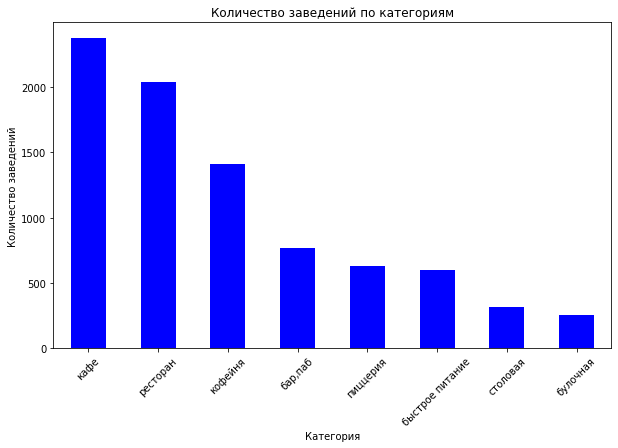

```python
# Группировка данных по категориям и подсчет количества
category_counts = data['category'].value_counts()

# Визуализация графика
plt.figure(figsize=(10, 6))
category_counts.plot(kind='bar', color='blue')
plt.xlabel('Категория')
plt.ylabel('Количество заведений')
plt.title('Количество заведений по категориям')
plt.xticks(rotation=45)
plt.show()
```

Самые популярные категорий - кафе, ресторан и кофейня. Наименее популярные - булочные и столовые

```python
# Шаг 3.2: Количество посадочных мест по категориям
seats_by_category = data.groupby('category')['seats'].sum()
print("Количество посадочных мест по категориям:")
print(seats_by_category)
```

```
Количество посадочных мест по категориям:
category
бар,паб             58281.0
булочная            13229.0
быстрое питание     34513.0
кафе               118770.0
кофейня             83511.0
пиццерия            40350.0
ресторан           154869.0
столовая            16359.0
Name: seats, dtype: float64
```

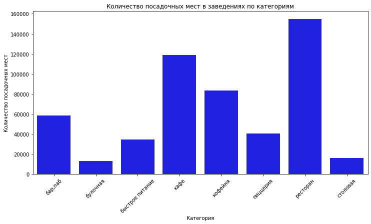

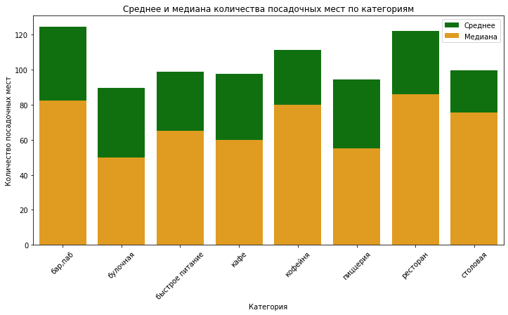

```python
# Группировка данных по категориям и суммирование посадочных мест
seats_by_category = data.groupby('category')['seats'].sum()

# Среднее и медиана количества посадочных мест по категориям
mean_seats = data.groupby('category')['seats'].mean()
median_seats = data.groupby('category')['seats'].median()

# Визуализация графиков
plt.figure(figsize=(12, 6))
sns.barplot(x=seats_by_category.index, y=seats_by_category.values, color='blue')
plt.xlabel('Категория')
plt.ylabel('Количество посадочных мест')
plt.title('Количество посадочных мест в заведениях по категориям')
plt.xticks(rotation=45)
plt.show()

plt.figure(figsize=(12, 6))
sns.barplot(x=mean_seats.index, y=mean_seats.values, color='green', label='Среднее')
sns.barplot(x=median_seats.index, y=median_seats.values, color='orange', label='Медиана')
plt.xlabel('Категория')
plt.ylabel('Количество посадочных мест')
plt.title('Среднее и медиана количества посадочных мест по категориям')
plt.xticks(rotation=45)
plt.legend()
plt.show()
```

Как мы видим на графиках, больше всего посадочных мест именно в трех самых популярных категориях заведений

```python
# Шаг 3.3: Соотношение сетевых и несетевых заведений
chain_counts = data['chain'].value_counts()
print("Соотношение сетевых и несетевых заведений:")
print(chain_counts)
```

```
Соотношение сетевых и несетевых заведений:
0    5201
1    3205
Name: chain, dtype: int64
```

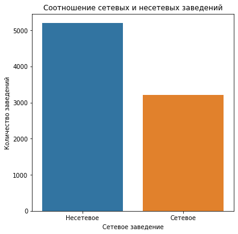

```python
# Визуализация соотношения сетевых и несетевых заведений
plt.figure(figsize=(6, 6))
sns.countplot(x='chain', data=data)
plt.xlabel('Сетевое заведение')
plt.ylabel('Количество заведений')
plt.title('Соотношение сетевых и несетевых заведений')
plt.xticks(ticks=[0, 1], labels=['Несетевое', 'Сетевое'])
plt.show()
```

Несетевых гораздо больше. Посмотрим распределение по категориям

```python
# Шаг 3.4: Категории заведений, которые чаще являются сетевыми
chain_categories = data[data['chain'] == 1]['category'].value_counts()
print("Категории заведений, которые чаще являются сетевыми:")
print(chain_categories)
```

```
Категории заведений, которые чаще являются сетевыми:
кафе               779
ресторан           730
кофейня            720
пиццерия           330
быстрое питание    232
бар,паб            169
булочная           157
столовая            88
Name: category, dtype: int64
```

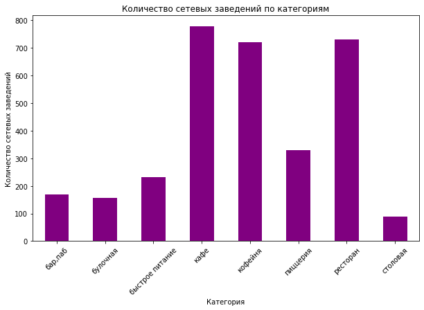

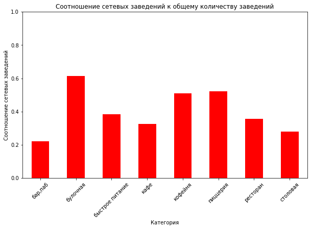

```python
# Группировка данных по категориям и подсчет количества сетевых заведений
chain_counts = data.groupby('category')['chain'].sum()

# Визуализация графика
plt.figure(figsize=(10, 6))
chain_counts.plot(kind='bar', color='purple')
plt.xlabel('Категория')
plt.ylabel('Количество сетевых заведений')
plt.title('Количество сетевых заведений по категориям')
plt.xticks(rotation=45)
plt.show()

# Соотношение сетевых заведений к общему количеству заведений каждого типа
total_counts = data['category'].value_counts()
ratio = chain_counts / total_counts

# Визуализация графика
plt.figure(figsize=(10, 6))
ratio.plot(kind='bar', color='red')
plt.xlabel('Категория')
plt.ylabel('Соотношение сетевых заведений')
plt.title('Соотношение сетевых заведений к общему количеству заведений')
plt.xticks(rotation=45)
plt.ylim((0, 1))
plt.show()
```

В процентном соотношении больше всего сетевых булочных, кофеен и пиццерий

```python
# Шаг 3.5: Топ-15 популярных сетей в Москве
top_chains = data[data['chain'] == 1]['name'].value_counts().nlargest(15)
print("Топ-15 популярных сетей в Москве:")
print(top_chains)
```

```
Топ-15 популярных сетей в Москве:
Шоколадница                            120
Домино'с Пицца                          76
Додо Пицца                              74
One Price Coffee                        71
Яндекс Лавка                            69
Cofix                                   65
Prime                                   50
Хинкальная                              44
КОФЕПОРТ                                42
Кулинарная лавка братьев Караваевых     39
Теремок                                 38
Чайхана                                 37
CofeFest                                32
Буханка                                 32
Му-Му                                   27
Name: name, dtype: int64
```

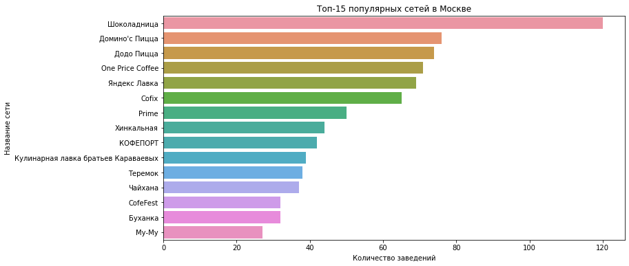

```python
# Визуализация топ-15 популярных сетей
plt.figure(figsize=(12, 6))
sns.barplot(x=top_chains.values, y=top_chains.index)
plt.xlabel('Количество заведений')
plt.ylabel('Название сети')
plt.title('Топ-15 популярных сетей в Москве')
plt.show()
```

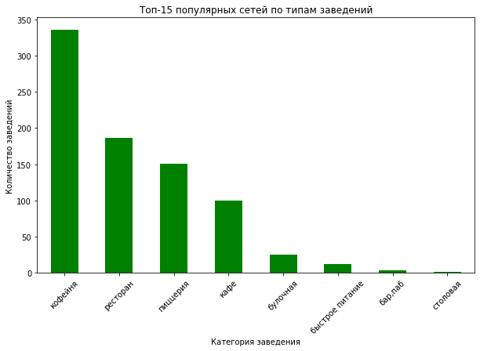

```python
# Визуализация топа по типам заведений
top_15_chains_categories = data[data['name'].isin(top_chains.index)]['category'].value_counts()

plt.figure(figsize=(10, 6))
top_15_chains_categories.plot(kind='bar', color='green')
plt.xlabel('Категория заведения')
plt.ylabel('Количество заведений')
plt.title('Топ-15 популярных сетей по типам заведений')
plt.xticks(rotation=45)
plt.show()
```

Самые популяные сети - кофейни. Такой перекос наверняка возник именно из-за "Шоколадницы", она бьет все рекорды. На стором месте - рестораны

```python
rating_by_district = data.groupby('district', as_index=False).agg({'rating':'mean'}).sort_values(by='rating', ascending=False)
geo_data= '/datasets/admin_level_geomap.geojson' # merged_data,



moscow_lat, moscow_lng = 55.751244, 37.618423
map = folium.Map(location=[moscow_lat, moscow_lng], zoom_start=13)

folium.Choropleth(
    geo_data=geo_data,  # Путь к геоданным административных районов
    data=rating_by_district,
    columns=['district', 'rating'],
    key_on='feature.properties.name',
    fill_color='YlGnBu',
    fill_opacity=0.7,
    line_opacity=0.2,
    legend_name='Средний рейтинг'
).add_to(map)

# Сохранение карты в HTML-файл
map.save('choropleth_map.html')
map
```

Make this Notebook Trusted to load map: File -> Trust Notebook

[interactive chart not shown]

Чем ближе к центру - тем выше рейтинг. Логично, Внутри МКАДа требования выше и требуются работники более высокой квалификации.

```python
data_by_street = data.groupby('street').agg(count=('name','count')).sort_values('count', ascending=False).reset_index()
data_by_street_top15 = data_by_street.head(15)
display(data_by_street_top15)

data_by_object_top15 = data[data['street'].isin(data_by_street_top15['street'].unique())]
df_2=data_by_object_top15.groupby(['street', 'category'], as_index=False).agg(count=('category', 'count')).sort_values(by = 'count',ascending = False)
df_2['total_count'] = df_2.groupby('street')['count'].transform('sum')
street_cat_sorted = df_2.sort_values('total_count')
```

|  | street | count |
| --- | --- | --- |
| 0 | проспект Мира | 184 |
| 1 | Профсоюзная улица | 122 |
| 2 | проспект Вернадского | 108 |
| 3 | Ленинский проспект | 107 |
| 4 | Ленинградский проспект | 95 |
| 5 | Дмитровское шоссе | 88 |
| 6 | Каширское шоссе | 77 |
| 7 | Варшавское шоссе | 76 |
| 8 | Ленинградское шоссе | 70 |
| 9 | МКАД | 65 |
| 10 | Люблинская улица | 60 |
| 11 | улица Вавилова | 55 |
| 12 | Кутузовский проспект | 54 |
| 13 | улица Миклухо-Маклая | 49 |
| 14 | Пятницкая улица | 48 |

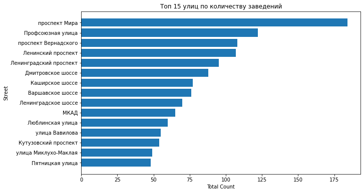

```python
plt.figure(figsize=(10, 6))
plt.barh(street_cat_sorted['street'], street_cat_sorted['total_count'])
plt.xlabel('Total Count')
plt.ylabel('Street')
plt.title('Топ 15 улиц по количеству заведений')
plt.show()
```

```python
# Нахождение улиц с только одним объектом общепита
streets_with_one_place = data['address'].str.split(',', n=1, expand=True)[1].value_counts().loc[lambda x: x == 1]
one_place_df = data[data['address'].str.split(',', n=1, expand=True)[1].isin(streets_with_one_place.index)]
one_place_df
```

|  | name | category | address | district | hours | lat | lng | rating | price | avg_bill | middle_avg_bill | middle_coffee_cup | chain | seats | street | is_24/7 |
| --- | --- | --- | --- | --- | --- | --- | --- | --- | --- | --- | --- | --- | --- | --- | --- | --- |
| 1 | Четыре комнаты | ресторан | Москва, улица Дыбенко, 36, корп. 1 | Северный административный округ | ежедневно, 10:00–22:00 | 55.875801 | 37.484479 | 4.5 | выше среднего | Средний счёт:1500–1600 ₽ | 1550.0 | NaN | 0 | 4.0 | улица Дыбенко | False |
| 2 | Хазри | кафе | Москва, Клязьминская улица, 15 | Северный административный округ | пн-чт 11:00–02:00; пт,сб 11:00–05:00; вс 11:00... | 55.889146 | 37.525901 | 4.6 | средние | Средний счёт:от 1000 ₽ | 1000.0 | NaN | 0 | 45.0 | Клязьминская улица | False |
| 3 | Dormouse Coffee Shop | кофейня | Москва, улица Маршала Федоренко, 12 | Северный административный округ | ежедневно, 09:00–22:00 | 55.881608 | 37.488860 | 5.0 | NaN | Цена чашки капучино:155–185 ₽ | NaN | 170.0 | 0 | NaN | улица Маршала Федоренко | False |
| 5 | Sergio Pizza | пиццерия | Москва, Ижорская улица, вл8Б | Северный административный округ | ежедневно, 10:00–23:00 | 55.888010 | 37.509573 | 4.6 | средние | NaN | NaN | NaN | 0 | NaN | Ижорская улица | False |
| 9 | Готика | кафе | Москва, Ангарская улица, 39 | Северный административный округ | ежедневно, 12:00–00:00 | 55.879038 | 37.524487 | 4.3 | средние | Средний счёт:1000–1200 ₽ | 1100.0 | NaN | 0 | 65.0 | Ангарская улица | False |
| ... | ... | ... | ... | ... | ... | ... | ... | ... | ... | ... | ... | ... | ... | ... | ... | ... |
| 8394 | Намангале | кафе | Москва, Ферганская улица, вл17-21 | Юго-Восточный административный округ | ежедневно, круглосуточно | 55.705332 | 37.819244 | 4.3 | NaN | NaN | NaN | NaN | 0 | NaN | Ферганская улица | True |
| 8395 | Истира Запрафка | кафе | Москва, Юго-Восточный административный округ, ... | Юго-Восточный административный округ | NaN | 55.724686 | 37.710558 | 2.9 | NaN | NaN | NaN | NaN | 0 | NaN | Юго-Восточный административный округ | NaN |
| 8397 | Траектория Крафт-Кафе | пиццерия | Москва, улица Лобачевского, 52, корп. 1 | Западный административный округ | пн-пт 10:00–23:00; сб,вс 12:00–23:00 | 55.672011 | 37.492628 | 4.4 | средние | NaN | NaN | NaN | 0 | 60.0 | улица Лобачевского | False |
| 8399 | Пекарня, кафе-гриль | булочная | Москва, Болотниковская улица, 52, корп. 2 | Юго-Западный административный округ | ежедневно, круглосуточно | 55.662866 | 37.582572 | 4.2 | NaN | Средний счёт:50–250 ₽ | 150.0 | NaN | 0 | 50.0 | Болотниковская улица | True |
| 8400 | Практика Кофе | кофейня | Москва, Чонгарский бульвар, 26А, корп. 1 | Юго-Западный административный округ | пн-пт 08:00–22:00; сб,вс 09:00–22:00 | 55.654289 | 37.600722 | 4.4 | NaN | NaN | NaN | NaN | 0 | 55.0 | Чонгарский бульвар | False |

4396 rows × 16 columns

Такой результат показывает нам, что есть довольно много хороших мест, чтобы открыть кофейню. И её одназначно следует делать сетевой. Также имеет смысл заключить контракт на поставку выпечки с известной сетью булочных - снизит нагрузку на кухню и не наплодит конкурентов, т.к. булочные не относятся к самым популярным заведеням.

```python
price_by_district = data.groupby('district', as_index=False).agg({'middle_avg_bill':'median'}).sort_values(by='middle_avg_bill', ascending=False)
geo_data= '/datasets/admin_level_geomap.geojson' # merged_data,



moscow_lat, moscow_lng = 55.751244, 37.618423
map = folium.Map(location=[moscow_lat, moscow_lng], zoom_start=13)

folium.Choropleth(
    geo_data=geo_data,  # Путь к геоданным административных районов
    data=price_by_district,
    columns=['district', 'middle_avg_bill'],
    key_on='feature.properties.name',
    fill_color='YlGnBu',
    fill_opacity=0.7,
    line_opacity=0.2,
    legend_name='Медианный средний чек'
).add_to(map)

# Сохранение карты в HTML-файл
map.save('choropleth_map.html')
map
```

Make this Notebook Trusted to load map: File -> Trust Notebook

[interactive chart not shown]

Лидируют Центральный район и Западный Адмиистративный округ. Логично, там район новая Москва и прописка приравнивается к Московской, значит, нужны соответстсвующие стандарты. Имеет смысл начать открываться из этого района (Новая Москва)- цены ставить такие же, как и у всех в этом районе, а на интерьер и квалификацию персонала сделать ставку как на фишку. Заведений с высоким рейтингом тут мало, будем выгодно отличаться. А свежайшая выпечка от в меру известной сети оттянет на себя часть их постоянных клиентов.

```python
# Анализ цен в Центральном административном округе и других
central_district = data[data['district'] == 'Центральный административный округ']
other_districts = data[data['district'] != 'Центральный административный округ']
display(central_district)
display(other_districts)
```

|  | name | category | address | district | hours | lat | lng | rating | price | avg_bill | middle_avg_bill | middle_coffee_cup | chain | seats | street | is_24/7 |
| --- | --- | --- | --- | --- | --- | --- | --- | --- | --- | --- | --- | --- | --- | --- | --- | --- |
| 1663 | Boston seafood & bar | ресторан | Москва, Лесная улица, 7 | Центральный административный округ | ежедневно, 12:00–00:00 | 55.778629 | 37.587275 | 4.9 | высокие | Средний счёт:2000–2500 ₽ | 2250.0 | NaN | 1 | 120.0 | Лесная улица | False |
| 1680 | ЧанЧан | ресторан | Москва, Лесная улица, 1/2 | Центральный административный округ | ежедневно, 11:00–23:00 | 55.776796 | 37.585577 | 4.6 | средние | Средний счёт:от 390 ₽ | 390.0 | NaN | 0 | 70.0 | Лесная улица | False |
| 1681 | Лао Ли Менделеев | кофейня | Москва, Миусская площадь, 9, стр. 11 | Центральный административный округ | ежедневно, 11:00–23:00 | 55.778627 | 37.596560 | 4.6 | средние | Средний счёт:300–500 ₽ | 400.0 | NaN | 0 | NaN | Миусская площадь | False |
| 1695 | Steak it easy | бар,паб | Москва, Лесная улица, 9 | Центральный административный округ | пн-чт 09:00–00:00; пт 09:00–06:00; сб 11:00–06... | 55.778891 | 37.588274 | 4.7 | выше среднего | Средний счёт:1300–1700 ₽ | 1500.0 | NaN | 1 | 130.0 | Лесная улица | False |
| 1696 | Дача Гашека | бар,паб | Москва, Долгоруковская улица, 31, стр. 32 | Центральный административный округ | пн-чт 12:00–00:00; пт,сб 12:00–03:00; вс 12:00... | 55.777440 | 37.601842 | 5.0 | выше среднего | Цена бокала пива:280 ₽ | NaN | NaN | 0 | 160.0 | Долгоруковская улица | False |
| ... | ... | ... | ... | ... | ... | ... | ... | ... | ... | ... | ... | ... | ... | ... | ... | ... |
| 8187 | ТК | кофейня | Москва, улица Щипок, 2 | Центральный административный округ | пн-пт 07:30–21:00; сб,вс 10:00–21:00 | 55.726413 | 37.628628 | 4.4 | NaN | NaN | NaN | NaN | 0 | 60.0 | улица Щипок | False |
| 8211 | Гранд Виктория | ресторан | Москва, улица Щипок, 16 | Центральный административный округ | ежедневно, 11:00–18:00 | 55.724654 | 37.633300 | 4.4 | NaN | NaN | NaN | NaN | 0 | NaN | улица Щипок | False |
| 8214 | Индимания | столовая | Москва, Люсиновская улица, 36, стр. 2 | Центральный административный округ | ежедневно, 10:00–22:00 | 55.722852 | 37.620501 | 4.3 | средние | Средний счёт:500–1050 ₽ | 775.0 | NaN | 0 | 150.0 | Люсиновская улица | False |
| 8225 | Won Cha | ресторан | Москва, улица Щипок, 2 | Центральный административный округ | ежедневно, 10:00–22:00 | 55.726457 | 37.628613 | 4.1 | NaN | NaN | NaN | NaN | 0 | 60.0 | улица Щипок | False |
| 8229 | Ибис Kitchen | ресторан | Москва, улица Щипок, 22, стр. 1 | Центральный административный округ | ежедневно, 07:00–22:00 | 55.723862 | 37.634616 | 4.0 | NaN | NaN | NaN | NaN | 0 | 42.0 | улица Щипок | False |

2242 rows × 16 columns

|  | name | category | address | district | hours | lat | lng | rating | price | avg_bill | middle_avg_bill | middle_coffee_cup | chain | seats | street | is_24/7 |
| --- | --- | --- | --- | --- | --- | --- | --- | --- | --- | --- | --- | --- | --- | --- | --- | --- |
| 0 | WoWфли | кафе | Москва, улица Дыбенко, 7/1 | Северный административный округ | ежедневно, 10:00–22:00 | 55.878494 | 37.478860 | 5.0 | NaN | NaN | NaN | NaN | 0 | NaN | улица Дыбенко | False |
| 1 | Четыре комнаты | ресторан | Москва, улица Дыбенко, 36, корп. 1 | Северный административный округ | ежедневно, 10:00–22:00 | 55.875801 | 37.484479 | 4.5 | выше среднего | Средний счёт:1500–1600 ₽ | 1550.0 | NaN | 0 | 4.0 | улица Дыбенко | False |
| 2 | Хазри | кафе | Москва, Клязьминская улица, 15 | Северный административный округ | пн-чт 11:00–02:00; пт,сб 11:00–05:00; вс 11:00... | 55.889146 | 37.525901 | 4.6 | средние | Средний счёт:от 1000 ₽ | 1000.0 | NaN | 0 | 45.0 | Клязьминская улица | False |
| 3 | Dormouse Coffee Shop | кофейня | Москва, улица Маршала Федоренко, 12 | Северный административный округ | ежедневно, 09:00–22:00 | 55.881608 | 37.488860 | 5.0 | NaN | Цена чашки капучино:155–185 ₽ | NaN | 170.0 | 0 | NaN | улица Маршала Федоренко | False |
| 4 | Иль Марко | пиццерия | Москва, Правобережная улица, 1Б | Северный административный округ | ежедневно, 10:00–22:00 | 55.881166 | 37.449357 | 5.0 | средние | Средний счёт:400–600 ₽ | 500.0 | NaN | 1 | 148.0 | Правобережная улица | False |
| ... | ... | ... | ... | ... | ... | ... | ... | ... | ... | ... | ... | ... | ... | ... | ... | ... |
| 8401 | Суши Мания | кафе | Москва, Профсоюзная улица, 56 | Юго-Западный административный округ | ежедневно, 09:00–02:00 | 55.670021 | 37.552480 | 4.4 | NaN | NaN | NaN | NaN | 0 | 86.0 | Профсоюзная улица | False |
| 8402 | Миславнес | кафе | Москва, Пролетарский проспект, 19, корп. 1 | Южный административный округ | ежедневно, 08:00–22:00 | 55.640875 | 37.656553 | 4.8 | NaN | NaN | NaN | NaN | 0 | 150.0 | Пролетарский проспект | False |
| 8403 | Самовар | кафе | Москва, Люблинская улица, 112А, стр. 1 | Юго-Восточный административный округ | ежедневно, круглосуточно | 55.648859 | 37.743219 | 3.9 | NaN | Средний счёт:от 150 ₽ | 150.0 | NaN | 0 | 150.0 | Люблинская улица | True |
| 8404 | Чайхана Sabr | кафе | Москва, Люблинская улица, 112А, стр. 1 | Юго-Восточный административный округ | ежедневно, круглосуточно | 55.648849 | 37.743222 | 4.2 | NaN | NaN | NaN | NaN | 1 | 150.0 | Люблинская улица | True |
| 8405 | Kebab Time | кафе | Москва, Россошанский проезд, 6 | Южный административный округ | ежедневно, круглосуточно | 55.598229 | 37.604702 | 3.9 | NaN | NaN | NaN | NaN | 0 | 12.0 | Россошанский проезд | True |

6164 rows × 16 columns

```python
west_district = data[data['district'] == 'Западный административный округ']
west_district
```

|  | name | category | address | district | hours | lat | lng | rating | price | avg_bill | middle_avg_bill | middle_coffee_cup | chain | seats | street | is_24/7 |
| --- | --- | --- | --- | --- | --- | --- | --- | --- | --- | --- | --- | --- | --- | --- | --- | --- |
| 1185 | Мужик у Плиты | бар,паб | Москва, посёлок Рублёво, Новолучанская улица, 21 | Западный административный округ | ежедневно, 11:00–21:30 | 55.791385 | 37.357339 | 5.0 | средние | Средний счёт:300–400 ₽ | 350.0 | NaN | 0 | NaN | посёлок Рублёво | False |
| 1218 | Рублёвский Базар | пиццерия | Москва, 2-я Мякининская улица, 50А, стр. 1 | Западный административный округ | пн-пт 10:00–23:00; сб,вс 11:00–23:00 | 55.809138 | 37.375383 | 4.3 | NaN | NaN | NaN | NaN | 0 | NaN | 2-я Мякининская улица | False |
| 1248 | Суши Wok | кафе | Москва, посёлок Рублёво, улица Василия Ботылёв... | Западный административный округ | ежедневно, 10:00–23:00 | 55.787938 | 37.355651 | 4.5 | NaN | NaN | NaN | NaN | 1 | NaN | посёлок Рублёво | False |
| 1252 | Шаурма | быстрое питание | Москва, 2-я Мякининская улица, 20 | Западный административный округ | ежедневно, 09:00–22:00 | 55.805264 | 37.374702 | 3.7 | NaN | NaN | NaN | NaN | 0 | NaN | 2-я Мякининская улица | False |
| 3004 | VASILCHUKÍ Chaihona №1 | ресторан | Москва, Рублёвское шоссе, 52А | Западный административный округ | пн-чт 11:00–00:00; пт,сб 11:00–02:00; вс 11:00... | 55.755050 | 37.403426 | 4.5 | выше среднего | Средний счёт:от 1500 ₽ | 1500.0 | NaN | 1 | NaN | Рублёвское шоссе | False |
| ... | ... | ... | ... | ... | ... | ... | ... | ... | ... | ... | ... | ... | ... | ... | ... | ... |
| 6838 | Alternative coffee | кофейня | Москва, проспект Вернадского, 41, стр. 1 | Западный административный округ | пн-пт 09:00–21:00; сб,вс 09:00–22:00 | 55.673128 | 37.502992 | 4.3 | NaN | NaN | NaN | NaN | 0 | 1288.0 | проспект Вернадского | False |
| 6843 | Чайхана Азия | кафе | Москва, Большая Очаковская улица, 47А, стр. 1 | Западный административный округ | ежедневно, 11:00–00:00 | 55.673926 | 37.440108 | 3.0 | NaN | NaN | NaN | NaN | 1 | 200.0 | Большая Очаковская улица | False |
| 6844 | Кафе | кафе | Москва, Озёрная улица, 33А | Западный административный округ | NaN | 55.670720 | 37.447464 | 3.1 | NaN | NaN | NaN | NaN | 0 | NaN | Озёрная улица | NaN |
| 8396 | Пекинский Двор | ресторан | Москва, Ленинский проспект, 158 | Западный административный округ | ежедневно, 11:00–23:00 | 55.651706 | 37.482667 | 4.3 | выше среднего | Средний счёт:1000–1500 ₽ | 1250.0 | NaN | 0 | 200.0 | Ленинский проспект | False |
| 8397 | Траектория Крафт-Кафе | пиццерия | Москва, улица Лобачевского, 52, корп. 1 | Западный административный округ | пн-пт 10:00–23:00; сб,вс 12:00–23:00 | 55.672011 | 37.492628 | 4.4 | средние | NaN | NaN | NaN | 0 | 60.0 | улица Лобачевского | False |

851 rows × 16 columns

```python
# Исследование часов работы заведений и их зависимость от расположения и категории
hours_by_district = data.groupby(['district', 'category'])['hours'].value_counts()
hours_by_district
```

```
district                          category  hours
Восточный административный округ  бар,паб   пн-чт 12:00–00:00; пт,сб 12:00–02:00; вс 12:00–00:00    7
                                            ежедневно, 12:00–00:00                                  5
                                            ежедневно, 12:00–23:00                                  4
                                            ежедневно, 09:00–00:00                                  2
                                            ежедневно, 10:00–23:00                                  2
                                                                                                   ..
Южный административный округ      столовая  пн-пт 09:00–23:00; сб,вс 10:00–23:00                    1
                                            пн-пт 11:00–16:00                                       1
                                            пн-пт 11:00–18:00                                       1
                                            пн-пт 11:30–16:00                                       1
                                            пн-сб 10:00–19:00                                       1
Name: hours, Length: 3555, dtype: int64
```

```python
# Исследование заведений с плохими рейтингами, средних чеков и распределения по категориям
low_rated_places = data[data['rating'] < 3]
avg_bill_by_category = data.groupby('category')['middle_avg_bill'].mean()
category_distribution = data['category'].value_counts()
category_distribution
```

```
кафе               2378
ресторан           2043
кофейня            1413
бар,паб             765
пиццерия            633
быстрое питание     603
столовая            315
булочная            256
Name: category, dtype: int64
```

```python
avg_bill_by_category
```

```
category
бар,паб            1338.762178
булочная            658.773585
быстрое питание     445.763713
кафе                707.753602
кофейня             614.210000
пиццерия            789.377215
ресторан           1367.881731
столовая            335.348066
Name: middle_avg_bill, dtype: float64
```

```python
low_rated_places
```

|  | name | category | address | district | hours | lat | lng | rating | price | avg_bill | middle_avg_bill | middle_coffee_cup | chain | seats | street | is_24/7 |
| --- | --- | --- | --- | --- | --- | --- | --- | --- | --- | --- | --- | --- | --- | --- | --- | --- |
| 47 | Кафе | кафе | Москва, улица Маршала Федоренко, 7 | Северный административный округ | ежедневно, 11:00–00:00 | 55.880306 | 37.489760 | 2.8 | NaN | NaN | NaN | NaN | 0 | 35.0 | улица Маршала Федоренко | False |
| 49 | 2U-Ту-Ю | пиццерия | Москва, Ижорская улица, 8А | Северный административный округ | ежедневно, круглосуточно | 55.886160 | 37.508784 | 2.7 | NaN | Средний счёт:900 ₽ | 900.0 | NaN | 0 | NaN | Ижорская улица | True |
| 56 | Рыба из тандыра | быстрое питание | Москва, Коровинское шоссе, 46, стр. 5 | Северный административный округ | NaN | 55.888010 | 37.515960 | 1.5 | NaN | NaN | NaN | NaN | 0 | NaN | Коровинское шоссе | NaN |
| 132 | Пекарня-шаурма | быстрое питание | Москва, Алтуфьевское шоссе, 84 | Северо-Восточный административный округ | ежедневно, круглосуточно | 55.895949 | 37.588100 | 2.0 | NaN | NaN | NaN | NaN | 0 | 4.0 | Алтуфьевское шоссе | True |
| 150 | Правда | бар,паб | Москва, Дмитровское шоссе, 124А | Северо-Восточный административный округ | ежедневно, 08:00–23:00 | 55.924367 | 37.549657 | 1.4 | NaN | NaN | NaN | NaN | 0 | NaN | Дмитровское шоссе | False |
| ... | ... | ... | ... | ... | ... | ... | ... | ... | ... | ... | ... | ... | ... | ... | ... | ... |
| 8221 | Дубровка | бар,паб | Москва, Шарикоподшипниковская улица, 13, стр. 3 | Юго-Восточный административный округ | пн-пт 08:00–02:00; сб,вс 08:00–03:00 | 55.717993 | 37.681637 | 1.3 | NaN | NaN | NaN | NaN | 0 | 70.0 | Шарикоподшипниковская улица | False |
| 8242 | Чайхона Шафран | ресторан | Москва, Южнопортовая улица, 5, стр. 16 | Юго-Восточный административный округ | пн-чт 11:00–00:00; пт,сб 11:00–02:00; вс 11:00... | 55.706707 | 37.689065 | 2.8 | NaN | NaN | NaN | NaN | 0 | 42.0 | Южнопортовая улица | False |
| 8314 | Фрегат | кафе | Москва, 8-я улица Текстильщиков, 11 | Юго-Восточный административный округ | пн-пт 09:00–17:00 | 55.703459 | 37.743814 | 1.3 | NaN | NaN | NaN | NaN | 0 | 96.0 | 8-я улица Текстильщиков | False |
| 8391 | Кафе Кенч | кафе | Москва, 1-я Новокузьминская улица, 3 | Юго-Восточный административный округ | ежедневно, 11:00–00:00 | 55.716771 | 37.785316 | 2.8 | NaN | NaN | NaN | NaN | 0 | 45.0 | 1-я Новокузьминская улица | False |
| 8395 | Истира Запрафка | кафе | Москва, Юго-Восточный административный округ, ... | Юго-Восточный административный округ | NaN | 55.724686 | 37.710558 | 2.9 | NaN | NaN | NaN | NaN | 0 | NaN | Юго-Восточный административный округ | NaN |

210 rows × 16 columns

```python
# Расчет медианы столбца middle_avg_bill для каждого района
median_prices = data.groupby('district')['middle_avg_bill'].median()
median_prices
```

```
district
Восточный административный округ            575.0
Западный административный округ            1000.0
Северный административный округ             650.0
Северо-Восточный административный округ     500.0
Северо-Западный административный округ      700.0
Центральный административный округ         1000.0
Юго-Восточный административный округ        450.0
Юго-Западный административный округ         600.0
Южный административный округ                500.0
Name: middle_avg_bill, dtype: float64
```

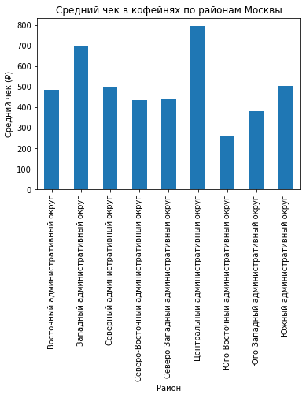

```python
# 1) Средний чек в кофейнях по разным районам Москвы
avg_bill_by_district = data[data['category'] == 'кофейня'].groupby('district')['middle_avg_bill'].mean()
avg_bill_by_district.plot(kind='bar', xlabel='Район', ylabel='Средний чек (₽)', title='Средний чек в кофейнях по районам Москвы')
plt.show()
```

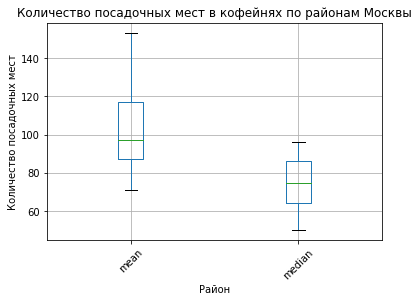

```python
# 2) Среднее и медианное количество посадочных мест в кофейнях разных районов Москвы (боксплот)
seats_by_district = data[data['category'] == 'кофейня'].groupby('district')['seats'].agg(['mean', 'median'])
seats_by_district.boxplot()
plt.xlabel('Район')
plt.ylabel('Количество посадочных мест')
plt.title('Количество посадочных мест в кофейнях по районам Москвы')
plt.xticks(rotation=45)
plt.show()
```

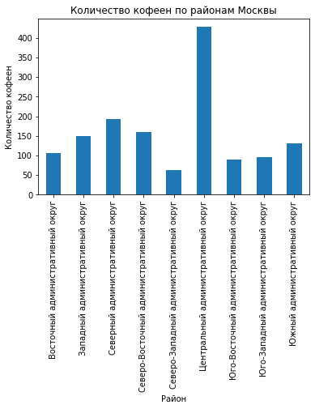

```python
# 3) Количество кофеен в разных районах Москвы
coffee_shops_by_district = data[data['category'] == 'кофейня'].groupby('district').size()
coffee_shops_by_district.plot(kind='bar', xlabel='Район', ylabel='Количество кофеен', title='Количество кофеен по районам Москвы')
plt.show()
```

```python
# Фильтрация данных по категории "кофейня"
coffee_shops = data[data['category'] == 'кофейня']

# Подсчет количества кофеен в каждом районе
coffee_shops_by_district = coffee_shops['district'].value_counts()

print("Количество кофеен по районам:")
print(coffee_shops_by_district)
```

```
Количество кофеен по районам:
Центральный административный округ         428
Северный административный округ            193
Северо-Восточный административный округ    159
Западный административный округ            150
Южный административный округ               131
Восточный административный округ           105
Юго-Западный административный округ         96
Юго-Восточный административный округ        89
Северо-Западный административный округ      62
Name: district, dtype: int64
```

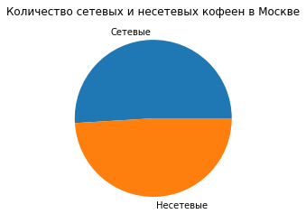

```python
# 4) Количество сетевых кофеен в Москве
chain_coffee_shops_count = data[data['category'] == 'кофейня']['chain'].sum()
non_chain_coffee_shops_count = data[data['category'] == 'кофейня'].shape[0] - chain_coffee_shops_count
plt.pie([chain_coffee_shops_count, non_chain_coffee_shops_count], labels=['Сетевые', 'Несетевые'])
plt.title('Количество сетевых и несетевых кофеен в Москве')
plt.show()
```

```python
# 5) Соотношение количества сетевых кофеен к несетевым
chain_ratio = chain_coffee_shops_count / non_chain_coffee_shops_count
print(f"Соотношение количества сетевых кофеен к несетевым: {chain_ratio:.2f}")
```

```
Соотношение количества сетевых кофеен к несетевым: 1.04
```

```python
# Фильтрация данных по категории "кофейня"
coffee_shops = data[data['category'] == 'кофейня']

# Группировка данных по адресам и подсчет количества кофеен на каждой улице
streets_with_coffee_shops = coffee_shops['address'].str.split(',').str[0].str.strip().value_counts()
# Формирование датафрейма с улицами, где нет или только одна кофейня
streets_with_few_coffee_shops = streets_with_coffee_shops[streets_with_coffee_shops >=1].reset_index()
streets_with_few_coffee_shops.columns = ['Улица', 'Количество кофеен']

# Вывод результата
print(streets_with_few_coffee_shops)
```

```
    Улица  Количество кофеен
0  Москва               1413
```

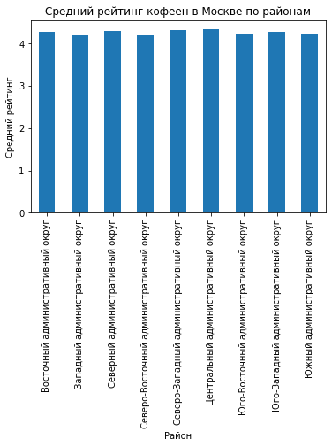

```python
# 7) Средний рейтинг кофеен в Москве по районам
avg_rating_by_district = data[data['category'] == 'кофейня'].groupby('district')['rating'].mean()
avg_rating_by_district.plot(kind='bar', xlabel='Район', ylabel='Средний рейтинг', title='Средний рейтинг кофеен в Москве по районам')
plt.show()
```

```python
# 8) Сформировать датафрейм с кофейнями Москвы, с сортировкой по среднему рейтингу
coffee_shops_moscow = data[data['category'] == 'кофейня']
coffee_shops_moscow_sorted_by_rating = coffee_shops_moscow.sort_values(by='rating', ascending=False)
display(coffee_shops_moscow_sorted_by_rating)
```

|  | name | category | address | district | hours | lat | lng | rating | price | avg_bill | middle_avg_bill | middle_coffee_cup | chain | seats | street | is_24/7 |
| --- | --- | --- | --- | --- | --- | --- | --- | --- | --- | --- | --- | --- | --- | --- | --- | --- |
| 3 | Dormouse Coffee Shop | кофейня | Москва, улица Маршала Федоренко, 12 | Северный административный округ | ежедневно, 09:00–22:00 | 55.881608 | 37.488860 | 5.0 | NaN | Цена чашки капучино:155–185 ₽ | NaN | 170.0 | 0 | NaN | улица Маршала Федоренко | False |
| 4408 | Bodrero | кофейня | Москва, улица Сретенка, 9 | Центральный административный округ | пн-пт 08:00–22:00; сб,вс 10:00–22:00 | 55.767602 | 37.631515 | 5.0 | NaN | NaN | NaN | NaN | 1 | 28.0 | улица Сретенка | False |
| 1283 | Pique-Nique | кофейня | Москва, 3-я Радиаторская улица, 9 | Северный административный округ | ежедневно, 09:00–22:00 | 55.818584 | 37.490628 | 5.0 | низкие | Цена чашки капучино:170–220 ₽ | NaN | 195.0 | 0 | NaN | 3-я Радиаторская улица | False |
| 1272 | Уголок | кофейня | Москва, улица Космонавта Волкова, 6А | Северный административный округ | пн-пт 08:00–21:00; сб,вс 09:00–21:00 | 55.815341 | 37.513262 | 5.0 | NaN | NaN | NaN | NaN | 1 | 180.0 | улица Космонавта Волкова | False |
| 5545 | Youtime | кофейня | Москва, Электродная улица, 2, стр. 32 | Восточный административный округ | ежедневно, 08:30–21:00 | 55.754323 | 37.752520 | 5.0 | NaN | NaN | NaN | NaN | 0 | 90.0 | Электродная улица | False |
| ... | ... | ... | ... | ... | ... | ... | ... | ... | ... | ... | ... | ... | ... | ... | ... | ... |
| 600 | В парке вкуснее | кофейня | Москва, Северный административный округ, район... | Северный административный округ | ежедневно, 10:00–21:00 | 55.851985 | 37.478492 | 2.2 | NaN | NaN | NaN | NaN | 1 | NaN | Северный административный округ | False |
| 6317 | Cofix | кофейня | Москва, улица Орджоникидзе, 11с1А | Южный административный округ | ежедневно, 10:00–22:00 | 55.708074 | 37.595851 | 2.0 | NaN | Цена чашки капучино:от 60 ₽ | NaN | 60.0 | 1 | NaN | улица Орджоникидзе | False |
| 605 | Cinnabon | кофейня | Москва, Беломорская улица, 16А | Северный административный округ | ежедневно, 10:00–22:00 | 55.862800 | 37.470965 | 2.0 | NaN | NaN | NaN | NaN | 1 | NaN | Беломорская улица | False |
| 1588 | КОФЕПОРТ | кофейня | Москва, 3-я Хорошёвская улица, 2, стр. 1 | Северо-Западный административный округ | пн-пт 08:00–18:30 | 55.777557 | 37.503128 | 2.0 | NaN | Цена чашки капучино:90–100 ₽ | NaN | 95.0 | 1 | 85.0 | 3-я Хорошёвская улица | False |
| 668 | Маракуйя | кофейня | Москва, Нововладыкинский проезд, 1к4 | Северо-Восточный административный округ | пн-пт 08:00–21:00; сб,вс 09:00–21:00 | 55.850976 | 37.575822 | 1.4 | NaN | NaN | NaN | NaN | 0 | NaN | Нововладыкинский проезд | False |

1413 rows × 16 columns

```python
# 9) Сформировать датафрейм с кофейнями Москвы, с сортировкой по среднему чеку
coffee_shops_moscow_sorted_by_avg_bill = coffee_shops_moscow.sort_values(by='middle_avg_bill', ascending=False)
display(coffee_shops_moscow_sorted_by_avg_bill)
```

|  | name | category | address | district | hours | lat | lng | rating | price | avg_bill | middle_avg_bill | middle_coffee_cup | chain | seats | street | is_24/7 |
| --- | --- | --- | --- | --- | --- | --- | --- | --- | --- | --- | --- | --- | --- | --- | --- | --- |
| 3685 | Кофемания | кофейня | Москва, Большая Никитская улица, 13 | Центральный административный округ | ежедневно, круглосуточно | 55.756507 | 37.604838 | 4.5 | высокие | Средний счёт:2500 ₽ | 2500.0 | NaN | 1 | 148.0 | Большая Никитская улица | True |
| 4008 | Кофемания | кофейня | Москва, Кутузовский проспект, 17 | Западный административный округ | ежедневно, круглосуточно | 55.746580 | 37.556662 | 4.4 | высокие | Средний счёт:2000–2500 ₽ | 2250.0 | NaN | 1 | 78.0 | Кутузовский проспект | True |
| 4756 | Кофемания | кофейня | Москва, Трубная площадь, 2 | Центральный административный округ | пн 06:00–00:00; вт-вс круглосуточно | 55.766739 | 37.621862 | 4.5 | высокие | Средний счёт:1500–2500 ₽ | 2000.0 | NaN | 1 | 120.0 | Трубная площадь | True |
| 4971 | Кофемания | кофейня | Москва, Садовническая улица, 82, стр. 2 | Центральный административный округ | пн-пт 08:00–00:00; сб,вс 10:00–00:00 | 55.734735 | 37.642786 | 4.4 | высокие | Средний счёт:1500–2500 ₽ | 2000.0 | NaN | 1 | 320.0 | Садовническая улица | False |
| 4568 | Кофемания | кофейня | Москва, Малый Черкасский переулок, 2 | Центральный административный округ | пн-пт 08:00–00:00; сб,вс 10:00–00:00 | 55.758633 | 37.626543 | 4.5 | высокие | Средний счёт:1500–2500 ₽ | 2000.0 | NaN | 1 | 175.0 | Малый Черкасский переулок | False |
| ... | ... | ... | ... | ... | ... | ... | ... | ... | ... | ... | ... | ... | ... | ... | ... | ... |
| 8356 | Назис Пури | кофейня | Москва, Люблинская улица, 61 | Юго-Восточный административный округ | ежедневно, 09:00–22:00 | 55.684103 | 37.738588 | 4.5 | NaN | NaN | NaN | NaN | 0 | NaN | Люблинская улица | False |
| 8365 | Квадрат кофе | кофейня | Москва, Волгоградский проспект, 73, стр. 1 | Юго-Восточный административный округ | пн-пт 08:30–21:30; сб,вс 09:00–21:30 | 55.709710 | 37.744450 | 4.2 | NaN | Цена чашки капучино:100–220 ₽ | NaN | 160.0 | 0 | 206.0 | Волгоградский проспект | False |
| 8376 | Шоколад имбирь корица | кофейня | Москва, Грайвороновская улица, 23 | Юго-Восточный административный округ | пн-пт 09:30–19:30 | 55.721213 | 37.740755 | 4.1 | NaN | NaN | NaN | NaN | 0 | NaN | Грайвороновская улица | False |
| 8385 | Cafio | кофейня | Москва, Новохохловская улица, 49 | Юго-Восточный административный округ | пн-пт 07:00–22:00; сб,вс 07:00–21:00 | 55.724357 | 37.716415 | 4.7 | NaN | Цена чашки капучино:80–120 ₽ | NaN | 100.0 | 0 | NaN | Новохохловская улица | False |
| 8400 | Практика Кофе | кофейня | Москва, Чонгарский бульвар, 26А, корп. 1 | Юго-Западный административный округ | пн-пт 08:00–22:00; сб,вс 09:00–22:00 | 55.654289 | 37.600722 | 4.4 | NaN | NaN | NaN | NaN | 0 | 55.0 | Чонгарский бульвар | False |

1413 rows × 16 columns

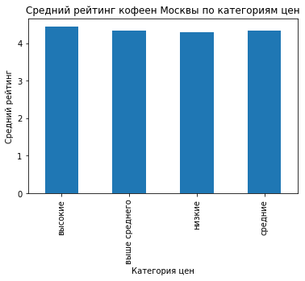

```python
# 10) Построить диаграмму среднего рейтинга кофеен Москвы по категориям цен
avg_rating_by_price = coffee_shops_moscow.groupby('price')['rating'].mean()
avg_rating_by_price.plot(kind='bar', xlabel='Категория цен', ylabel='Средний рейтинг', title='Средний рейтинг кофеен Москвы по категориям цен')
plt.show()
```

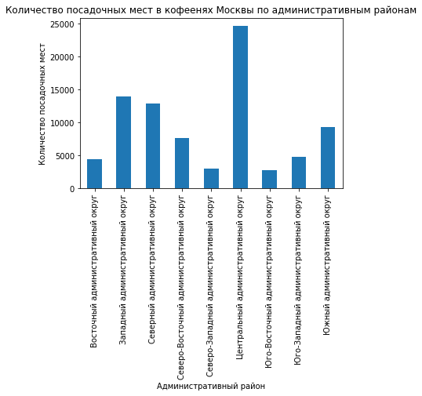

```python
# 11) Построить диаграмму количества посадочных мест в кофеенях Москвы по административным районам
seats_by_district = coffee_shops_moscow.groupby('district')['seats'].sum()
seats_by_district.plot(kind='bar', xlabel='Административный район', ylabel='Количество посадочных мест', title='Количество посадочных мест в кофеенях Москвы по административным районам')
plt.show()
```

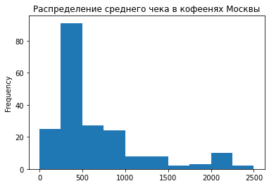

```python
# 12) Построить диаграмму распределения среднего чека в кофеенях Москвы
avg_bill_distribution = coffee_shops_moscow['middle_avg_bill']
avg_bill_distribution.plot(kind='hist', bins=10, xlabel='Средний чек (₽)', ylabel='Частота', title='Распределение среднего чека в кофеенях Москвы')
plt.show()
```

```python
# Группировка данных по району и вычисление медианного среднего чека
median_avg_bill_by_district = coffee_shops.groupby('district')['middle_avg_bill'].median()

# Группировка данных по району и вычисление средней и медианной цены чашки капучино
mean_coffee_price_by_district = coffee_shops.groupby('district')['middle_coffee_cup'].mean()
median_coffee_price_by_district = coffee_shops.groupby('district')['middle_coffee_cup'].median()

# Группировка данных по району и вычисление среднего и медианного количества посадочных мест
mean_seats_by_district = coffee_shops.groupby('district')['seats'].mean()
median_seats_by_district = coffee_shops.groupby('district')['seats'].median()

# Вывод результатов
print("Медианный средний чек кофеен по районам:")
print(median_avg_bill_by_district)
print("\nСредняя цена чашки капучино по районам:")
print(mean_coffee_price_by_district)
print("\nМедианная цена чашки капучино по районам:")
print(median_coffee_price_by_district)
print("\nСреднее количество посадочных мест в кофейнях по районам:")
print(mean_seats_by_district)
print("\nМедианное количество посадочных мест в кофейнях по районам:")
print(median_seats_by_district)
```

```
Медианный средний чек кофеен по районам:
district
Восточный административный округ           400.0
Западный административный округ            600.0
Северный административный округ            325.0
Северо-Восточный административный округ    325.0
Северо-Западный административный округ     325.0
Центральный административный округ         500.0
Юго-Восточный административный округ       250.0
Юго-Западный административный округ        375.0
Южный административный округ               387.5
Name: middle_avg_bill, dtype: float64

Средняя цена чашки капучино по районам:
district
Восточный административный округ           174.023810
Западный административный округ            189.938776
Северный административный округ            165.789474
Северо-Восточный административный округ    165.333333
Северо-Западный административный округ     165.523810
Центральный административный округ         187.518519
Юго-Восточный административный округ       151.088235
Юго-Западный административный округ        184.176471
Южный административный округ               158.488372
Name: middle_coffee_cup, dtype: float64

Медианная цена чашки капучино по районам:
district
Восточный административный округ           135.0
Западный административный округ            189.0
Северный административный округ            159.0
Северо-Восточный административный округ    162.5
Северо-Западный административный округ     165.0
Центральный административный округ         190.0
Юго-Восточный административный округ       147.5
Юго-Западный административный округ        198.0
Южный административный округ               150.0
Name: middle_coffee_cup, dtype: float64

Среднее количество посадочных мест в кофейнях по районам:
```

[output cut: 9 more lines]

```
Южный административный округ               124.973333
Name: seats, dtype: float64

Медианное количество посадочных мест в кофейнях по районам:
district
Восточный административный округ           55.0
Западный административный округ            96.0
Северный административный округ            66.0
Северо-Восточный административный округ    75.0
Северо-Западный административный округ     87.5
Центральный административный округ         86.0
Юго-Восточный административный округ       50.0
Юго-Западный административный округ        64.5
Южный административный округ               80.0
Name: seats, dtype: float64
```

ССЫЛКА НА ПРЕЗЕНТАЦИЮ https://docs.google.com/presentation/d/13PYxzOMBCpLLhopca62SQwJuOaCi8m9x/edit?usp=drive_link&ouid=104121326397313414126&rtpof=true&sd=true